# Project 1: Bringing it All Together

Mason Henrie

2024-05-28

How long does an LED light bulb last?

It depends on the model you use!

# Background

How long does the intensity of a single LED light bulb last? For this project, we’ve obtained LED light bulb #35 using a seed of 40633. The lumens of light bulb #35 are measured 44 times during the duration of 5000 hours (208 days). The goal for this project is to predict the brightness of the bulb as a function of how long it’s been on.

# Data

```r
library(data4led)
bulb <- led_bulb(1,seed = 40633)

library(pander)
pander(head(bulb))
```

|  | id | hours | intensity | normalized_intensity | percent_intensity |
| --- | --- | --- | --- | --- | --- |
| **1497** | 35 | 0 | 777.3 | 1 | 100 |
| **1498** | 35 | 26 | 779.2 | 1.002 | 100.2 |
| **1499** | 35 | 91 | 791.9 | 1.019 | 101.9 |
| **1500** | 35 | 192 | 785.6 | 1.011 | 101.1 |
| **1501** | 35 | 293 | 783.6 | 1.008 | 100.8 |
| **1502** | 35 | 403 | 780.7 | 1.004 | 100.4 |

# The Six Models

Function 0 is a constant function.

$$f_0(x; a_0) = a_0, \quad \text{where } x \geq 0$$

Function 1 is a linear function.

$$f_1(x; a_0, a_1) = a_0 + a_1 x, \quad \text{where } x \geq 0$$

Function 2 is a quadratic function.

$$f_2(x; a_0, a_1, a_2) = a_0 + a_1 x + a_2 x^2, \quad \text{where } x
\geq 0$$

Function 3 is an exponential decay function.

$$f_3(x; a_0, a_1, a_2) = a_0 + a_1 e^{-a_2 x}, \quad \text{where } x \geq
0$$

Function 4 combines a linear term with a logarithmic term.

$$f_4(x; a_0, a_1, a_2) = a_0 + a_1 x + a_2 \ln(0.005x + 1), \quad
\text{where } x \geq 0$$

Function 5 is a product of a linear function and an exponential decay function.

$$f_5(x; a_0, a_1, a_2) = (a_0 + a_1 x)e^{-a_2 x}, \quad \text{where } x
\geq 0$$

# How I will fit the models

I will fit the models onto the data by making it so the line is within close proximity of the dots.

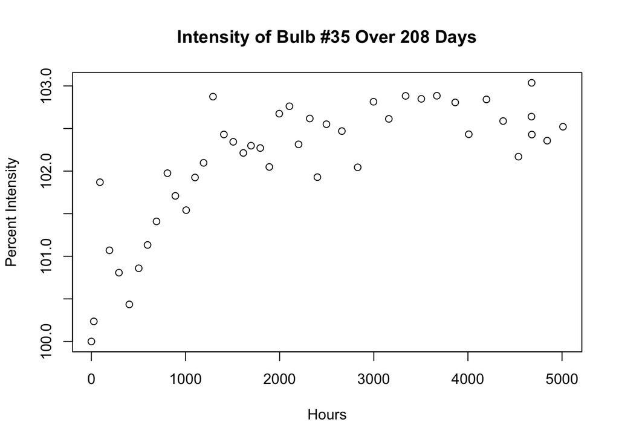

```r
plot(percent_intensity ~ hours, data = bulb,
     main = "Intensity of Bulb #35 Over 208 Days",
     xlab = "Hours",
     ylab = "Percent Intensity")
```

# Function 0

$f_0(0, a_0=100) = 100$

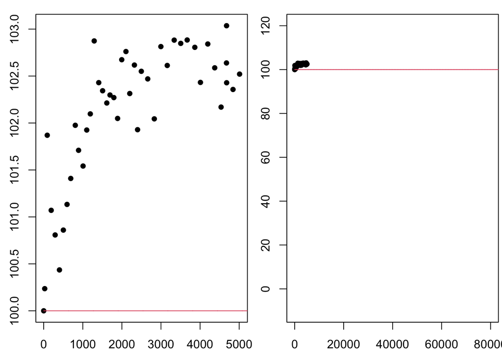

```r
library(data4led)
bulb <- led_bulb(1,seed = 40633)

t <- bulb$hours
y1 <- bulb$percent_intensity

f0 <- function(x,a0=1){a0 + 0*x}
x <- seq(0,100000,5)
y2 <- f0(x,a0=100)

par(mfrow=c(1,2),mar=c(2.5,2.5,1,0.25))
plot(t,y1,xlab="Hour", ylab="Intensity(%) ", pch=16)
lines(x,y2,col=2)
plot(t,y1,xlab="Hour", ylab="Intensity(%) ", pch=16, xlim = c(0,80000),ylim = c(-10,120))
lines(x,y2,col=2)
```

With function 0 fitted, the light bulb has an infinite constant power. A super hero might want their hands on this!

This model is inconsistent with the information we know about light bulbs and should not be used.

# Function 1

$f_1(0, a_0=100, a_2=.0009) = 100 + .0009(0) = 100$

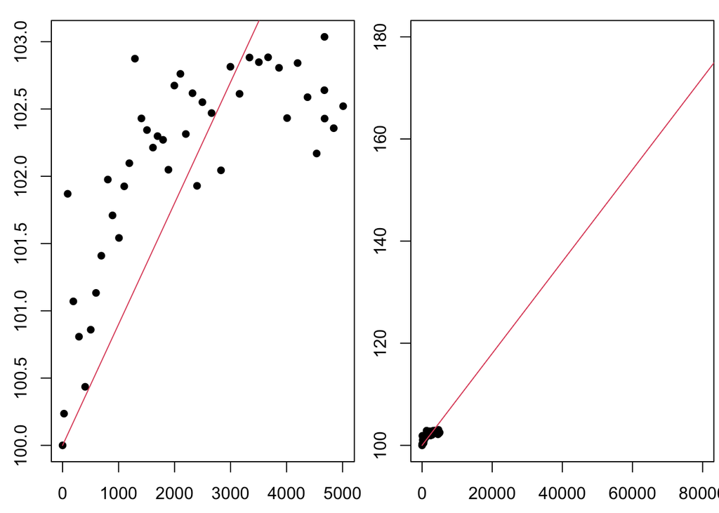

```r
library(data4led)
bulb <- led_bulb(1,seed = 40633)

t <- bulb$hours
y1 <- bulb$percent_intensity

f1 <- function(t, a0, a1) {
  a0 + a1 * t
}
x <- seq(0,100000,5)
y3 <- f1(x,a0=100,a1=.0009) # not a0=100

par(mfrow=c(1,2),mar=c(2.5,2.5,1,0.25))
plot(t,y1,xlab="Hour", ylab="Intensity(%) ", pch=16)
lines(x,y3,col=2)
plot(t,y1,xlab="Hour", ylab="Intensity(%) ", pch=16, xlim = c(0,80000),ylim = c(100,180))
lines(x,y3,col=2)
```

With function 1 fitted, we can predict the light bulb will get 1% brighter every 1000 hours. This bulb is sure taking its time.

This model is inconsistent with the information we know about light bulbs and should not be used.

# Function 2

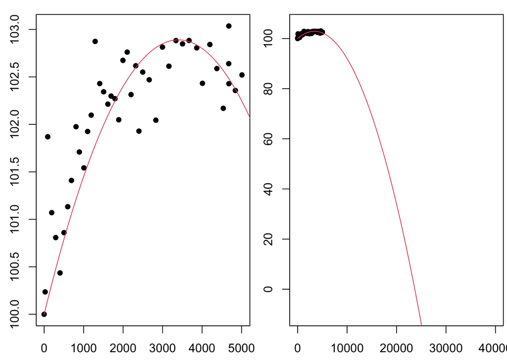

```r
library(data4led)
bulb <- led_bulb(1,seed = 40633)

t <- bulb$hours
y1 <- bulb$percent_intensity

f2 <- function(t, a0, a1, a2) {
  a0 + a1 * t + a2 * t^2
}
x <- seq(0,100000,5)
y4 <- f2(x,a0=100,a1=.0017,a2=-.00000025)
#y4 <- f2(x,a0=100,a1=.00065,a2=.0000001)

par(mfrow=c(1,2),mar=c(2.5,2.5,1,0.25))
plot(t,y1,xlab="Hour", ylab="Intensity(%) ", pch=16)
lines(x,y4,col=2)
plot(t,y1,xlab="Hour", ylab="Intensity(%) ", pch=16, xlim = c(0,40000),ylim = c(-10,105))
lines(x,y4,col=2)
```

With function 2 fitted, we can expect to replace this bulb in 1.3 years.

This model is consistent with the information we know about light bulbs and might be used.

# Function 3

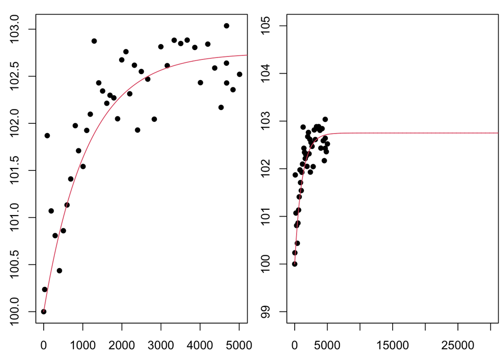

```r
library(data4led)
bulb <- led_bulb(1,seed = 40633)

t <- bulb$hours
y1 <- bulb$percent_intensity

f3 <- function(t, a0, a1, a2) {
  a0 + a1 * exp(-a2 * t)
}
x <- seq(0,100000,5)
y5 <- f3(x,a0=102.75,a1=-2.75,a2=0.0009)
#y5 <- f3(x,a0=99,a1=1,a2=-.0004) # not a0=100

par(mfrow=c(1,2),mar=c(2.5,2.5,1,0.25))
plot(t,y1,xlab="Hour", ylab="Intensity(%) ", pch=16)
lines(x,y5,col=2)
plot(t,y1,xlab="Hour", ylab="Intensity(%) ", pch=16, xlim = c(0,30000),ylim = c(99,105))
lines(x,y5,col=2)
```

With function 3 fitted, we can expect this light bulb to burn at a constant rate forever! This would appear to be the perfect bulb.

This model is inconsistent with the information we know about light bulbs and should not be used.

# Function 4

$f_4(0; a_0 = 100, a_1 = 0, a_2 = .93) = 100 + 0(0) + .93\ln(0.005(0) + 1) = 100$

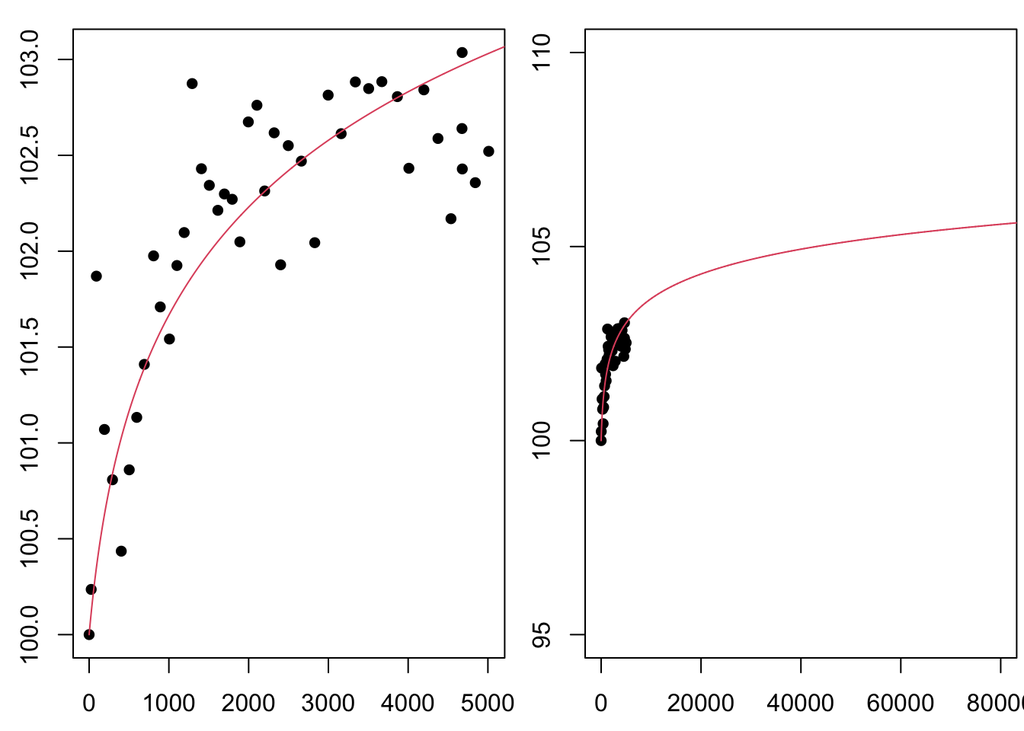

```r
library(data4led)
bulb <- led_bulb(1,seed = 40633)

t <- bulb$hours
y1 <- bulb$percent_intensity

f4 <- function(t, a0, a1, a2) {
  a0 + a1 * t + a2 * log(0.005 * t + 1)
}
x <- seq(0,100000,5)
#y6 <- f4(x,a0=100,a1=-1.81e-4,a2=0.83)
y6 <- f4(x,a0=100,a1=0,a2=.93) # not a0=100

par(mfrow=c(1,2),mar=c(2.5,2.5,1,0.25))
plot(t,y1,xlab="Hour", ylab="Intensity(%) ", pch=16)
lines(x,y6,col=2)
plot(t,y1,xlab="Hour", ylab="Intensity(%) ", pch=16, xlim = c(0,80000),ylim = c(95,110))
lines(x,y6,col=2)
```

With function 4 fitted, we can expect rapid growth within the first 2 months but a slight dying increase afterward.

This model is inconsistent with the information we know about light bulbs and should not be used.

# Function 5

$f_5(0; a_0 = 100, a_1 = .01035, a_2 = .00008) = (100 + .01035(0))e^{-.00008t} = 100$

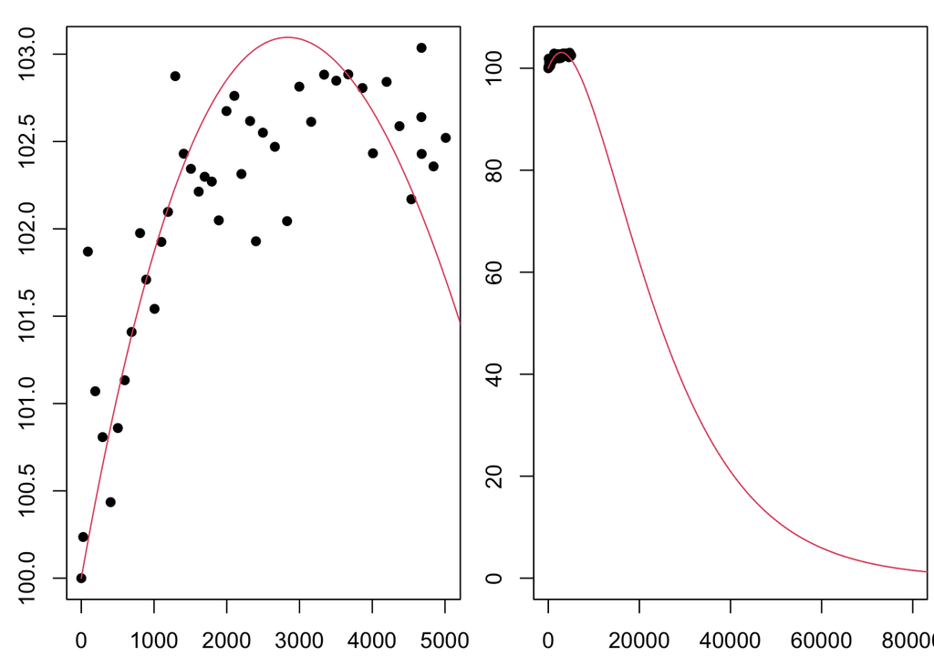

```r
library(data4led)
bulb <- led_bulb(1,seed = 40633)

t <- bulb$hours
y1 <- bulb$percent_intensity

f5 <- function(t, a0, a1, a2) {
  (a0 + a1 * t) * exp(-a2 * t)
}
x <- seq(0,100000,5)
y7 <- f5(x,a0=100,a1=.01035,a2=.00008) # not a0=100

par(mfrow=c(1,2),mar=c(2.5,2.5,1,0.25))
plot(t,y1,xlab="Hour", ylab="Intensity(%) ", pch=16)
lines(x,y7,col=2)
plot(t,y1,xlab="Hour", ylab="Intensity(%) ", pch=16, xlim = c(0,80000),ylim = c(0,104))
lines(x,y7,col=2)
```

This model is consistent with the information we know about light bulbs and could be used. Overall, of the 6 functions we used, only functions 2 and 5 display realistic stories of a light bulb. Function 5 might be my favorite because it has a slow decreasing line towards the end of its life.

# Project Reflection

Project 1 was quite interesting and I’d like to explain the mathematical ideas I’ve learned. We created models to ultimately predict the life span of a light bulb. Just because the model fits the data, does NOT mean the model will perfectly predict the story. Like Howard Skipper once said: “A model is a lie that helps you see the truth.” Moving forward, I’d like to remember the uniroot function, as it certainly helps when finding the x-intercept. From this project I’ve also learned how to create functions with inputs which will indefinitely come in handy.

Throughout the project, I’ve retained the importance of following directions. I’ve resubmitted this project’s tasks multiple times because of lack of complete reading. When completing any assignment, it’s important to know the full story and directions! Overall, this was a great project and I had a blast.